# Courcework

```python
# Import Libraries
# 01.To handle the data
import pandas as pd
import numpy as np
# 02.To visualize the data
import matplotlib.pyplot as plt
import seaborn as sns
import plotly.express as px

# 03. To preprocess the data
from sklearn.preprocessing import LabelEncoder,OneHotEncoder,StandardScaler

# 04. import iterative imputer
from sklearn.experimental import enable_iterative_imputer
from sklearn.impute import IterativeImputer
# 05. Machine Learning Models
from sklearn.model_selection import train_test_split,cross_val_score,GridSearchCV
from sklearn.ensemble import RandomForestClassifier, RandomForestRegressor
# 06. Metrics for classification task
from sklearn.metrics import accuracy_score,confusion_matrix,classification_report,roc_auc_score,roc_curve
from sklearn.metrics import confusion_matrix, ConfusionMatrixDisplay
# 07. Metrics for regression (used in imputation functions)
from sklearn.metrics import mean_absolute_error, mean_squared_error, r2_score
from sklearn.pipeline import Pipeline
# ignore warnings
import warnings
warnings.filterwarnings('ignore')
# Set the resolution of the plotted figures
plt.rcParams['figure.dpi'] = 150
```

## 1. Data Loading and Initial Exploration

Load the heart disease dataset and examine its structure, dimensions, and basic statistics.

```python
df = pd.read_csv("heart_disease_uci (1).csv")
# print the first 5 rows
df.head(5)
```

|  | id | age | sex | dataset | cp | trestbps | chol | fbs | restecg | thalch | exang | oldpeak | slope | ca | thal | num |
| --- | --- | --- | --- | --- | --- | --- | --- | --- | --- | --- | --- | --- | --- | --- | --- | --- |
| 0 | 1 | 63 | Male | Cleveland | typical angina | 145.0 | 233.0 | True | lv hypertrophy | 150.0 | False | 2.3 | downsloping | 0.0 | fixed defect | 0 |
| 1 | 2 | 67 | Male | Cleveland | asymptomatic | 160.0 | 286.0 | False | lv hypertrophy | 108.0 | True | 1.5 | flat | 3.0 | normal | 2 |
| 2 | 3 | 67 | Male | Cleveland | asymptomatic | 120.0 | 229.0 | False | lv hypertrophy | 129.0 | True | 2.6 | flat | 2.0 | reversable defect | 1 |
| 3 | 4 | 37 | Male | Cleveland | non-anginal | 130.0 | 250.0 | False | normal | 187.0 | False | 3.5 | downsloping | 0.0 | normal | 0 |
| 4 | 5 | 41 | Female | Cleveland | atypical angina | 130.0 | 204.0 | False | lv hypertrophy | 172.0 | False | 1.4 | upsloping | 0.0 | normal | 0 |

```python
# Exploring the data type of each column
df.info()
```

```
<class 'pandas.core.frame.DataFrame'>
RangeIndex: 920 entries, 0 to 919
Data columns (total 16 columns):
 #   Column    Non-Null Count  Dtype
---  ------    --------------  -----
 0   id        920 non-null    int64
 1   age       920 non-null    int64
 2   sex       920 non-null    object
 3   dataset   920 non-null    object
 4   cp        920 non-null    object
 5   trestbps  861 non-null    float64
 6   chol      890 non-null    float64
 7   fbs       830 non-null    object
 8   restecg   918 non-null    object
 9   thalch    865 non-null    float64
 10  exang     865 non-null    object
 11  oldpeak   858 non-null    float64
 12  slope     611 non-null    object
 13  ca        309 non-null    float64
 14  thal      434 non-null    object
 15  num       920 non-null    int64
dtypes: float64(5), int64(3), object(8)
memory usage: 115.1+ KB
```

```python
# Summary statistics of the dataframe
df.describe(include="all").T
```

|  | count | unique | top | freq | mean | std | min | 25% | 50% | 75% | max |
| --- | --- | --- | --- | --- | --- | --- | --- | --- | --- | --- | --- |
| id | 920.0 | NaN | NaN | NaN | 460.5 | 265.725422 | 1.0 | 230.75 | 460.5 | 690.25 | 920.0 |
| age | 920.0 | NaN | NaN | NaN | 53.51087 | 9.424685 | 28.0 | 47.0 | 54.0 | 60.0 | 77.0 |
| sex | 920 | 2 | Male | 726 | NaN | NaN | NaN | NaN | NaN | NaN | NaN |
| dataset | 920 | 4 | Cleveland | 304 | NaN | NaN | NaN | NaN | NaN | NaN | NaN |
| cp | 920 | 4 | asymptomatic | 496 | NaN | NaN | NaN | NaN | NaN | NaN | NaN |
| trestbps | 861.0 | NaN | NaN | NaN | 132.132404 | 19.06607 | 0.0 | 120.0 | 130.0 | 140.0 | 200.0 |
| chol | 890.0 | NaN | NaN | NaN | 199.130337 | 110.78081 | 0.0 | 175.0 | 223.0 | 268.0 | 603.0 |
| fbs | 830 | 2 | False | 692 | NaN | NaN | NaN | NaN | NaN | NaN | NaN |
| restecg | 918 | 3 | normal | 551 | NaN | NaN | NaN | NaN | NaN | NaN | NaN |
| thalch | 865.0 | NaN | NaN | NaN | 137.545665 | 25.926276 | 60.0 | 120.0 | 140.0 | 157.0 | 202.0 |
| exang | 865 | 2 | False | 528 | NaN | NaN | NaN | NaN | NaN | NaN | NaN |
| oldpeak | 858.0 | NaN | NaN | NaN | 0.878788 | 1.091226 | -2.6 | 0.0 | 0.5 | 1.5 | 6.2 |
| slope | 611 | 3 | flat | 345 | NaN | NaN | NaN | NaN | NaN | NaN | NaN |
| ca | 309.0 | NaN | NaN | NaN | 0.676375 | 0.935653 | 0.0 | 0.0 | 0.0 | 1.0 | 3.0 |
| thal | 434 | 3 | normal | 196 | NaN | NaN | NaN | NaN | NaN | NaN | NaN |
| num | 920.0 | NaN | NaN | NaN | 0.995652 | 1.142693 | 0.0 | 0.0 | 1.0 | 2.0 | 4.0 |

## Exploratory Data Visualization

The following plots provide a quick visual understanding of the dataset before modeling.

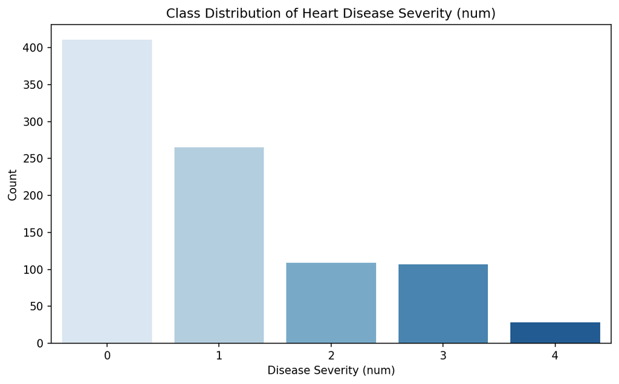

```python
# Bar plot: class distribution of heart disease severity (num)
plt.figure(figsize=(8, 5))
order = sorted(df['num'].dropna().unique())
sns.countplot(data=df, x='num', order=order, palette='Blues')
plt.title('Class Distribution of Heart Disease Severity (num)')
plt.xlabel('Disease Severity (num)')
plt.ylabel('Count')
plt.tight_layout()
plt.show()
```

The class distribution is imbalanced: class 0 is the most frequent while severe class 4 appears rarely. This means the model will see far fewer high-severity cases, so stratified splits and metrics beyond accuracy are important to avoid bias toward the majority class.

[figure not shown]

```python
# Histograms for numerical features
numeric_features = df.select_dtypes(include='number').drop(columns=['id', 'num'], errors='ignore')
numeric_features.hist(figsize=(12, 8), bins=20)
plt.suptitle('Histograms of Numeric Features', fontsize=14)
plt.tight_layout()
plt.show()
```

```
dataset
Cleveland        304
Hungary          293
VA Long Beach    200
Switzerland      123
Name: count, dtype: int64

Total Records: 920

Distribution by Source:
  Cleveland: 304 records (33.0%)
  Hungary: 293 records (31.8%)
  VA Long Beach: 200 records (21.7%)
  Switzerland: 123 records (13.4%)
```

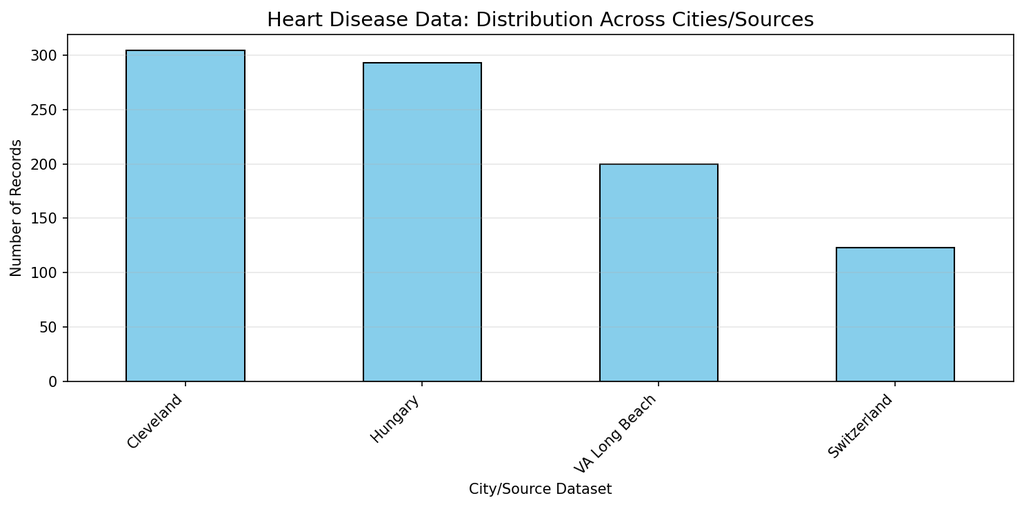

```python
# Data Source: Different Cities/Locations
if 'dataset' in df.columns:
    dataset_dist = df['dataset'].value_counts()
    print(f"\n{dataset_dist}")
    print(f"\nTotal Records: {len(df)}")
    print(f"\nDistribution by Source:")
    for source, count in dataset_dist.items():
        pct = (count / len(df)) * 100
        print(f"  {source}: {count} records ({pct:.1f}%)")
else:
    print("Note: 'dataset' column not found in dataframe")
    print(f"Available columns: {df.columns.tolist()}")

# Visualize data distribution across cities
fig, ax = plt.subplots(figsize=(10, 5))
dataset_dist.plot(kind='bar', ax=ax, color='skyblue', edgecolor='black')
plt.title('Heart Disease Data: Distribution Across Cities/Sources', fontsize=14)
plt.xlabel('City/Source Dataset')
plt.ylabel('Number of Records')
plt.xticks(rotation=45, ha='right')
plt.grid(axis='y', alpha=0.3)
plt.tight_layout()
plt.show()
```

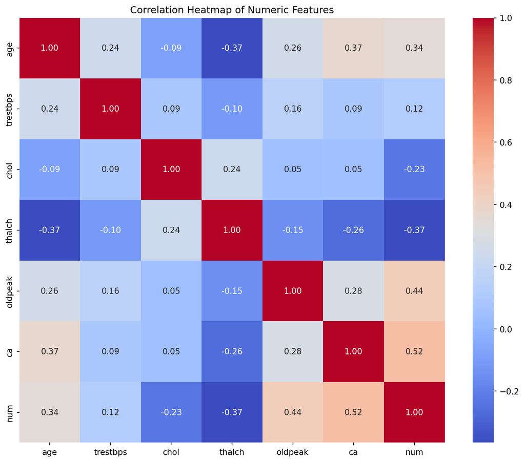

```python
# Correlation heatmap for numeric features (including target)
corr_cols = numeric_features.columns.tolist() + ['num']
corr = df[corr_cols].corr(numeric_only=True)
plt.figure(figsize=(10, 8))
sns.heatmap(corr, annot=True, fmt='.2f', cmap='coolwarm', square=True)
plt.title('Correlation Heatmap of Numeric Features')
plt.tight_layout()
plt.show()
```

The heatmap shows moderate relationships between the target (`num`) and features like `ca` and `oldpeak`, while `thalch` is negatively correlated with `num`. Most feature-feature correlations are not extreme, suggesting limited multicollinearity among numeric predictors.

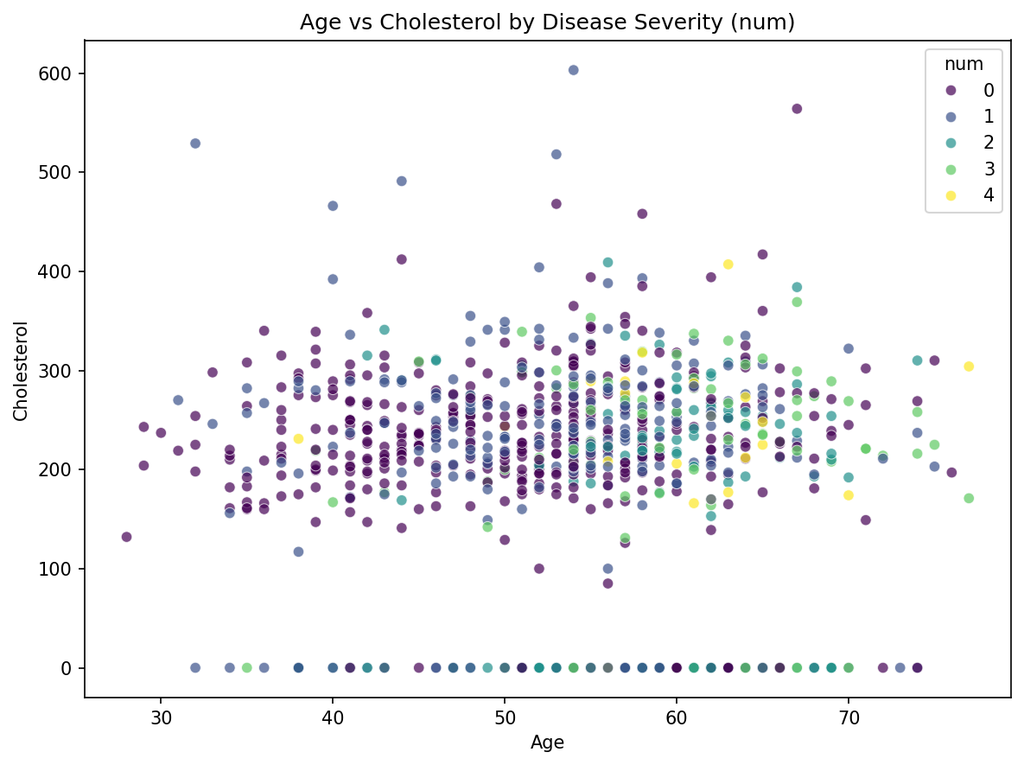

```python
# Scatter plot to inspect relationships (age vs cholesterol)
plt.figure(figsize=(8, 6))
sns.scatterplot(data=df, x='age', y='chol', hue='num', palette='viridis', alpha=0.7)
plt.title('Age vs Cholesterol by Disease Severity (num)')
plt.xlabel('Age')
plt.ylabel('Cholesterol')
plt.tight_layout()
plt.show()
```

The scatter plot shows substantial overlap between severity classes across both age and cholesterol, which suggests that no simple linear boundary separates the classes. This supports trying non-linear models (e.g., Random Forest, SVM with non-linear kernels) in addition to linear baselines.

```python
# plot the histogram of age column using plotly and coloring this by sex
fig = px.histogram(data_frame=df, x='age', color= 'sex')
fig.show()
```

[output not shown]

### Distribution Analysis by Disease Status

Analyze feature distributions separated by disease presence/absence to identify predictive patterns.

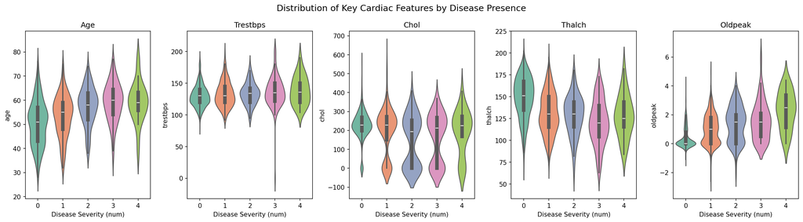

```python
# Violin plots: Compare distributions of numeric features by disease presence
numeric_cols_for_viz = ['age', 'trestbps', 'chol', 'thalch', 'oldpeak']

fig, axes = plt.subplots(1, 5, figsize=(18, 5))
fig.suptitle('Distribution of Key Cardiac Features by Disease Presence', fontsize=14)

for idx, col in enumerate(numeric_cols_for_viz):
    sns.violinplot(data=df, x='num', y=col, ax=axes[idx], palette='Set2')
    axes[idx].set_title(f'{col.capitalize()}')
    axes[idx].set_xlabel('Disease Severity (num)')

plt.tight_layout()
plt.show()
```

```python
skew_df = pd.DataFrame({
    "Feature": numeric_cols,
    "Skewness": [skew(df[col].dropna()) for col in numeric_cols]
}).sort_values(by="Skewness", key=lambda s: s.abs(), ascending=False)

print("Skewness of Numeric Features (sorted by |skewness|):")
print(skew_df.to_string(index=False))
```

```
Skewness of Numeric Features (sorted by |skewness|):
 Feature  Skewness
 oldpeak  0.832795
    chol -0.647590
     age -0.195674
trestbps  0.154151
  thalch -0.132572
```

### Feature Relationships and Pairplot Analysis

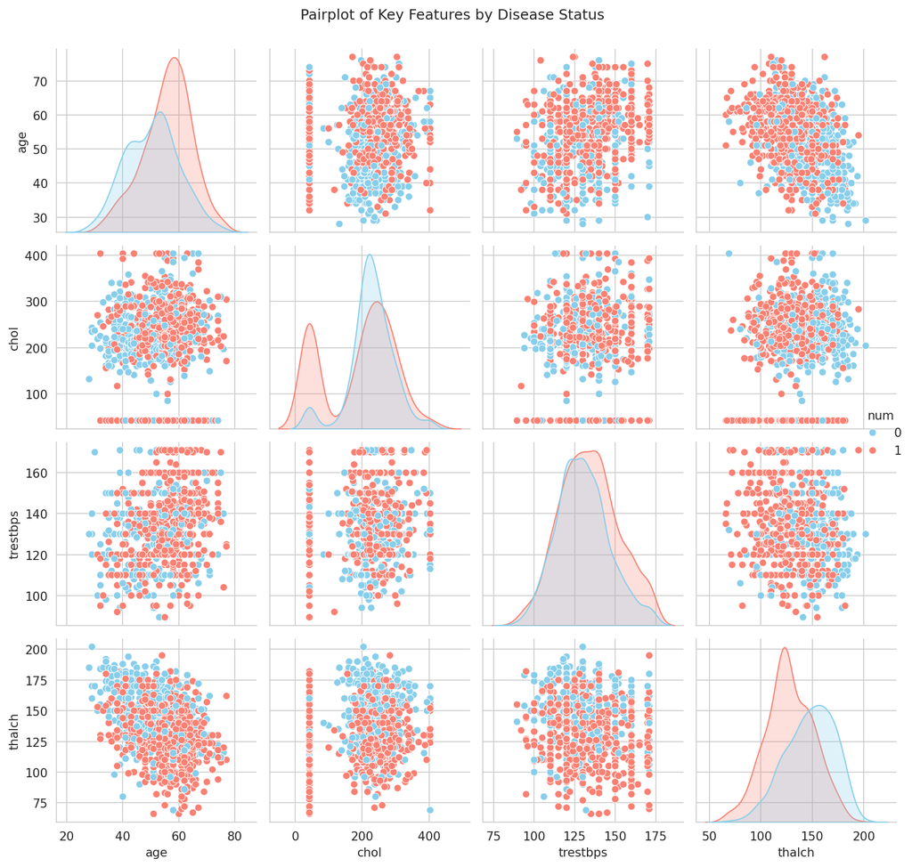

```python
# Pairplot for key features colored by disease status
# Select key features for pairplot (limit for readability)
pair_cols = ['age', 'chol', 'trestbps', 'thalch', 'num']
pair_data = df[pair_cols].copy()
pair_data['num'] = (pair_data['num'] > 0).astype(int)  # Binary: 0=no disease, 1=disease

# Create pairplot
sns.set_style("whitegrid")
pairplot_fig = sns.pairplot(pair_data, hue='num', palette=['skyblue', 'salmon'], diag_kind='kde')
pairplot_fig.fig.suptitle('Pairplot of Key Features by Disease Status', y=1.001)
plt.tight_layout()
plt.show()
```

### Categorical Feature Analysis

Analyze the distribution and relationship of categorical features with disease status.

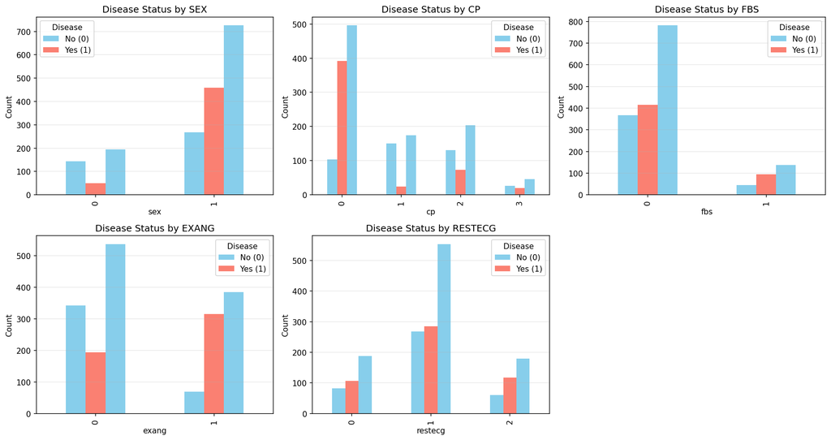

```python
# Create a temporary binary target for categorical analysis
df_binary = df.copy()
df_binary['disease'] = (df_binary['num'] > 0).astype(int)

# Select key categorical features for analysis
key_cat_features = ['sex', 'cp', 'fbs', 'exang', 'restecg']

# Create stacked bar charts for categorical features
fig, axes = plt.subplots(2, 3, figsize=(15, 8))
axes = axes.flatten()

for idx, col in enumerate(key_cat_features):
    if col in df_binary.columns:
        # Create crosstab for better visualization
        ct = pd.crosstab(df_binary[col], df_binary['disease'], margins=True)
        ct_pct = pd.crosstab(df_binary[col], df_binary['disease'], normalize='index') * 100

        # Plot stacked bar
        ct.iloc[:-1, :].plot(kind='bar', ax=axes[idx], color=['skyblue', 'salmon'])
        axes[idx].set_title(f'Disease Status by {col.upper()}')
        axes[idx].set_xlabel(col)
        axes[idx].set_ylabel('Count')
        axes[idx].legend(title='Disease', labels=['No (0)', 'Yes (1)'])
        axes[idx].grid(axis='y', alpha=0.3)

# Remove the last empty subplot
axes[-1].remove()

plt.tight_layout()
plt.show()
```

### Target Variable Analysis

Analyze the distribution and severity levels of heart disease in the dataset.

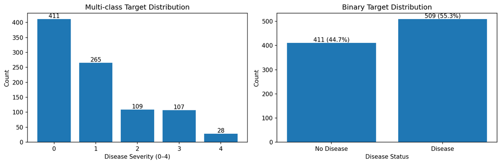

```python
import matplotlib.pyplot as plt

# Create side-by-side plots
fig, axes = plt.subplots(1, 2, figsize=(12, 4))


mc_counts = df['num'].value_counts().sort_index()

axes[0].bar(mc_counts.index, mc_counts.values)
axes[0].set_xlabel("Disease Severity (0–4)")
axes[0].set_ylabel("Count")
axes[0].set_title("Multi-class Target Distribution")

# Add count labels
for x, y in zip(mc_counts.index, mc_counts.values):
    axes[0].text(x, y, y, ha='center', va='bottom')


bin_counts = df_binary['disease'].value_counts().sort_index()

axes[1].bar(bin_counts.index, bin_counts.values)
axes[1].set_xlabel("Disease Status")
axes[1].set_ylabel("Count")
axes[1].set_title("Binary Target Distribution")
axes[1].set_xticks([0, 1])
axes[1].set_xticklabels(["No Disease", "Disease"])

# Add count + percentage
total = len(df_binary)
for x, y in zip(bin_counts.index, bin_counts.values):
    pct = (y / total) * 100
    axes[1].text(x, y, f"{y} ({pct:.1f}%)", ha='center', va='bottom')

plt.tight_layout()
plt.show()
```

### Age and Sex Demographics

Analyze demographic patterns in the dataset related to age and gender.

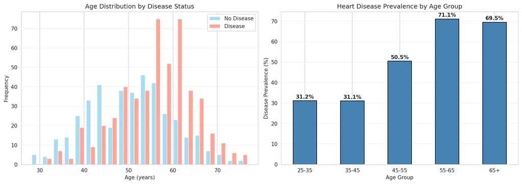

```python
# Age distribution analysis
fig, axes = plt.subplots(1, 2, figsize=(14, 5))

# Age histogram by disease status
axes[0].hist([df_binary[df_binary['disease']==0]['age'],
              df_binary[df_binary['disease']==1]['age']],
             label=['No Disease', 'Disease'], color=['skyblue', 'salmon'], bins=20, alpha=0.7)
axes[0].set_xlabel('Age (years)')
axes[0].set_ylabel('Frequency')
axes[0].set_title('Age Distribution by Disease Status')
axes[0].legend()
axes[0].grid(axis='y', alpha=0.3)

# Disease prevalence by age groups
age_bins = [25, 35, 45, 55, 65, 80]
age_labels = ['25-35', '35-45', '45-55', '55-65', '65+']
df_binary['age_group'] = pd.cut(df_binary['age'], bins=age_bins, labels=age_labels)

age_disease = df_binary.groupby('age_group')['disease'].agg(['sum', 'count'])
age_disease['prevalence_%'] = (age_disease['sum'] / age_disease['count'] * 100).round(1)

age_disease['prevalence_%'].plot(kind='bar', ax=axes[1], color='steelblue', edgecolor='black')
axes[1].set_xlabel('Age Group')
axes[1].set_ylabel('Disease Prevalence (%)')
axes[1].set_title('Heart Disease Prevalence by Age Group')
axes[1].set_xticklabels(age_labels, rotation=0)
axes[1].grid(axis='y', alpha=0.3)

# Add percentage labels
for i, v in enumerate(age_disease['prevalence_%']):
    axes[1].text(i, v + 1, f'{v:.1f}%', ha='center', fontweight='bold')

plt.tight_layout()
plt.show()
```

```python
# Checking coulmns for missing values
(df.isnull().sum()/ len(df)* 100).sort_values(ascending=False)
```

```
ca          66.413043
thal        52.826087
slope       33.586957
fbs          9.782609
oldpeak      6.739130
trestbps     6.413043
exang        5.978261
thalch       5.978261
chol         3.260870
restecg      0.217391
cp           0.000000
dataset      0.000000
id           0.000000
age          0.000000
sex          0.000000
num          0.000000
dtype: float64
```

## 2. Data Preprocessing and Missing Value Imputation

Handle missing values using iterative imputation with Random Forest for both categorical and numerical features.

```python
# Identify the columns in which the data is missing.
round((df.isnull().sum()[df.isnull().sum()>0]/len(df)*100),1).sort_values(ascending=False)
```

```
ca          66.4
thal        52.8
slope       33.6
fbs          9.8
oldpeak      6.7
trestbps     6.4
exang        6.0
thalch       6.0
chol         3.3
restecg      0.2
dtype: float64
```

```python
missing_data_cols = df.isnull().sum()[df.isnull().sum() > 0].index.tolist()
missing_data_cols
```

```
['trestbps',
 'chol',
 'fbs',
 'restecg',
 'thalch',
 'exang',
 'oldpeak',
 'slope',
 'ca',
 'thal']
```

```python
# find only categorical columns
cat_cols = df.select_dtypes(include='object').columns.tolist()
# find only numerical columns
num_cols = df.select_dtypes(exclude='object').columns.tolist()

print(f'Categorical Columns: {cat_cols}')
print(f'Numerical Columns: {num_cols}')
```

```
Categorical Columns: ['sex', 'dataset', 'cp', 'fbs', 'restecg', 'exang', 'slope', 'thal']
Numerical Columns: ['id', 'age', 'trestbps', 'chol', 'thalch', 'oldpeak', 'ca', 'num']
```

```python
categorical_cols = ['thal', 'ca', 'slope', 'exang', 'restecg', 'fbs', 'cp', 'sex', 'num']
bool_cols = ['fbs', 'exang']
numeric_cols = ['oldpeak', 'thalch', 'chol', 'trestbps', 'age']
```

# Define the function to impute the missing values in thal column

```python
def impute_categorical_missing_data(passed_col):

    df_null = df[df[passed_col].isnull()]
    df_not_null = df[df[passed_col].notnull()]

    X = df_not_null.drop(passed_col, axis=1)
    y = df_not_null[passed_col]

    other_missing_cols = [col for col in missing_data_cols if col != passed_col]

    label_encoder = LabelEncoder()

    for col in X.columns:
        if X[col].dtype == 'object' or X[col].dtype == 'category':
            X[col] = label_encoder.fit_transform(X[col])

    if passed_col in bool_cols:
        y = label_encoder.fit_transform(y)

    iterative_imputer = IterativeImputer(estimator=RandomForestRegressor(random_state=42), add_indicator=True)

    for col in other_missing_cols:
        if X[col].isnull().sum() > 0:
            col_with_missing_values = X[col].values.reshape(-1, 1)
            imputed_values = iterative_imputer.fit_transform(col_with_missing_values)
            X[col] = imputed_values[:, 0]
        else:
            pass

    X_train, X_test, y_train, y_test = train_test_split(X, y, test_size=0.2, random_state=42)

    rf_classifier = RandomForestClassifier()

    rf_classifier.fit(X_train, y_train)

    y_pred = rf_classifier.predict(X_test)

    acc_score = accuracy_score(y_test, y_pred)

    print("The feature '"+ passed_col+ "' has been imputed with", round((acc_score * 100), 2), "accuracy\n")

    X = df_null.drop(passed_col, axis=1)

    for col in X.columns:
        if X[col].dtype == 'object' or X[col].dtype == 'category':
            X[col] = label_encoder.fit_transform(X[col])

    for col in other_missing_cols:
        if X[col].isnull().sum() > 0:
            col_with_missing_values = X[col].values.reshape(-1, 1)
            imputed_values = iterative_imputer.fit_transform(col_with_missing_values)
            X[col] = imputed_values[:, 0]
        else:
            pass

    if len(df_null) > 0:
        df_null[passed_col] = rf_classifier.predict(X)
        if passed_col in bool_cols:
            df_null[passed_col] = df_null[passed_col].map({0: False, 1: True})
        else:
            pass
    else:
        pass

    df_combined = pd.concat([df_not_null, df_null])

    return df_combined[passed_col]

def impute_continuous_missing_data(passed_col):

    df_null = df[df[passed_col].isnull()]
    df_not_null = df[df[passed_col].notnull()]

    X = df_not_null.drop(passed_col, axis=1)
    y = df_not_null[passed_col]

    other_missing_cols = [col for col in missing_data_cols if col != passed_col]

    label_encoder = LabelEncoder()

    for col in X.columns:
        if X[col].dtype == 'object' or X[col].dtype == 'category':
            X[col] = label_encoder.fit_transform(X[col])

    iterative_imputer = IterativeImputer(estimator=RandomForestRegressor(random_state=42), add_indicator=True)

    for col in other_missing_cols:
        if X[col].isnull().sum() > 0:
            col_with_missing_values = X[col].values.reshape(-1, 1)
            imputed_values = iterative_imputer.fit_transform(col_with_missing_values)
            X[col] = imputed_values[:, 0]
        else:
            pass

    X_train, X_test, y_train, y_test = train_test_split(X, y, test_size=0.2, random_state=42)

    rf_regressor = RandomForestRegressor(random_state=42)

    rf_regressor.fit(X_train, y_train)

    y_pred = rf_regressor.predict(X_test)

    # Fixed: Use np.sqrt() for RMSE calculation instead of squared parameter
    mae = mean_absolute_error(y_test, y_pred)
    mse = mean_squared_error(y_test, y_pred)
    rmse = np.sqrt(mse)
    r2 = r2_score(y_test, y_pred)

    print(f"The feature '{passed_col}' imputation metrics:")
    print(f"MAE = {mae:.4f}")
    print(f"RMSE = {rmse:.4f}")
    print(f"R2 = {r2:.4f}\n")

    X = df_null.drop(passed_col, axis=1)

    for col in X.columns:
        if X[col].dtype == 'object' or X[col].dtype == 'category':
            X[col] = label_encoder.fit_transform(X[col])

    for col in other_missing_cols:
        if X[col].isnull().sum() > 0:
            col_with_missing_values = X[col].values.reshape(-1, 1)
            imputed_values = iterative_imputer.fit_transform(col_with_missing_values)
            X[col] = imputed_values[:, 0]
        else:
            pass

    if len(df_null) > 0:
        df_null[passed_col] = rf_regressor.predict(X)
    else:
        pass

    df_combined = pd.concat([df_not_null, df_null])

    return df_combined[passed_col]
```

```python
categorical_cols = ['thal', 'ca', 'slope', 'exang', 'restecg', 'fbs', 'cp', 'sex']
numerical_cols = ['oldpeak', 'thalch', 'chol', 'trestbps', 'age']
bool_cols = ['fbs', 'exang']
```

```python
for col in missing_data_cols:
    print(f"Processing: {col}")
    print(f"Missing Values: {str(round((df[col].isnull().sum() / len(df)) * 100, 2))}%")

    if col in categorical_cols:
        # Use categorical imputation function
        df[col] = impute_categorical_missing_data(col)
    elif col in numerical_cols:
        # Use continuous imputation function
        df[col] = impute_continuous_missing_data(col)
    else:
        print(f"Column {col} not in any category, skipping...\n")


print(df.isnull().sum().sort_values(ascending=False))
print(f"\nTotal missing values: {df.isnull().sum().sum()}")
```

```
Processing: trestbps
Missing Values: 6.41%
The feature 'trestbps' imputation metrics:
MAE = 13.3668
RMSE = 17.3952
R2 = 0.0552

Processing: chol
Missing Values: 3.26%
The feature 'chol' imputation metrics:
MAE = 45.7275
RMSE = 64.8377
R2 = 0.6670

Processing: fbs
Missing Values: 9.78%
The feature 'fbs' has been imputed with 78.31 accuracy

Processing: restecg
Missing Values: 0.22%
The feature 'restecg' has been imputed with 65.22 accuracy

Processing: thalch
Missing Values: 5.98%
The feature 'thalch' imputation metrics:
MAE = 16.6689
RMSE = 21.5894
R2 = 0.3223

Processing: exang
Missing Values: 5.98%
The feature 'exang' has been imputed with 79.19 accuracy

Processing: oldpeak
Missing Values: 6.74%
The feature 'oldpeak' imputation metrics:
MAE = 0.5635
RMSE = 0.7964
R2 = 0.3958

```

[output cut: 16 more lines]

```
cp          0
trestbps    0
chol        0
fbs         0
restecg     0
thalch      0
exang       0
oldpeak     0
slope       0
ca          0
thal        0
num         0
dtype: int64

Total missing values: 0
```

```python
# Identify the unique values in each categorical column.
for col in df.columns:
    if df[col].dtype == 'object' or df[col].dtype == 'category':
        print(col, ":", df[col].unique(), '\n')
```

```
sex : ['Male' 'Female']

dataset : ['Cleveland' 'Hungary' 'Switzerland' 'VA Long Beach']

cp : ['typical angina' 'asymptomatic' 'non-anginal' 'atypical angina']

fbs : [True False]

restecg : ['lv hypertrophy' 'normal' 'st-t abnormality']

exang : [False True]

slope : ['downsloping' 'flat' 'upsloping']

thal : ['fixed defect' 'normal' 'reversable defect']
```

```python
# let's see which columns has missing values
(df.isnull().sum()/ len(df)* 100).sort_values(ascending=False)
```

```
id          0.0
age         0.0
sex         0.0
dataset     0.0
cp          0.0
trestbps    0.0
chol        0.0
fbs         0.0
restecg     0.0
thalch      0.0
exang       0.0
oldpeak     0.0
slope       0.0
ca          0.0
thal        0.0
num         0.0
dtype: float64
```

```python
categorical_cols = ['thal', 'ca', 'slope', 'exang', 'restecg','fbs', 'cp', 'sex', 'num']
# Encode the categorical columns using label encoding.
label_encoder = LabelEncoder()

for col in df.columns:
    if df[col].dtype == 'object' or df[col].dtype == 'category':
        df[col] = label_encoder.fit_transform(df[col])
```

```python
Q1 = df[num_cols].quantile(0.25)
Q3 = df[num_cols].quantile(0.75)
IQR = Q3 - Q1
outliers_count_specified = ((df[num_cols] < (Q1 - 1.5 * IQR)) | (df[num_cols] > (Q3 + 1.5 * IQR))).sum()

outliers_count_specified
```

```
id            0
age           0
trestbps     28
chol        185
thalch        2
oldpeak       3
ca           21
num           0
dtype: int64
```

## 5. Outlier Detection and Treatment

Detect and handle outliers using IQR (Interquartile Range) method with capping strategy.

```python
# Detect outliers using IQR method and apply capping
print("OUTLIER DETECTION & TREATMENT (IQR Method)")
outlier_stats = {}

for col in numeric_cols:
    Q1 = df[col].quantile(0.25)
    Q3 = df[col].quantile(0.75)
    IQR = Q3 - Q1
    lower_bound = Q1 - 1.5 * IQR
    upper_bound = Q3 + 1.5 * IQR

    # Count outliers before treatment
    outliers_before = ((df[col] < lower_bound) | (df[col] > upper_bound)).sum()
    outlier_stats[col] = {
        'lower': lower_bound,
        'upper': upper_bound,
        'count': outliers_before,
        'pct': (outliers_before / len(df)) * 100
    }

    print(f"\n{col.upper()}:")
    print(f"  Range: [{lower_bound:.2f}, {upper_bound:.2f}]")
    print(f"  Outliers: {outliers_before} ({outlier_stats[col]['pct']:.1f}%)")

    # Apply capping (winsorization) - replace extreme values with bounds
    df[col] = df[col].clip(lower_bound, upper_bound)


print(f"Total outliers capped: {sum(s['count'] for s in outlier_stats.values())}")
print(f"Data rows preserved: {len(df)}\n")
```

```
OUTLIER DETECTION & TREATMENT (IQR Method)

OLDPEAK:
  Range: [-2.85, 4.75]
  Outliers: 3 (0.3%)

THALCH:
  Range: [66.00, 210.00]
  Outliers: 2 (0.2%)

CHOL:
  Range: [42.38, 403.38]
  Outliers: 185 (20.1%)

TRESTBPS:
  Range: [89.41, 170.99]
  Outliers: 28 (3.0%)

AGE:
  Range: [27.50, 79.50]
  Outliers: 0 (0.0%)
Total outliers capped: 218
Data rows preserved: 920
```

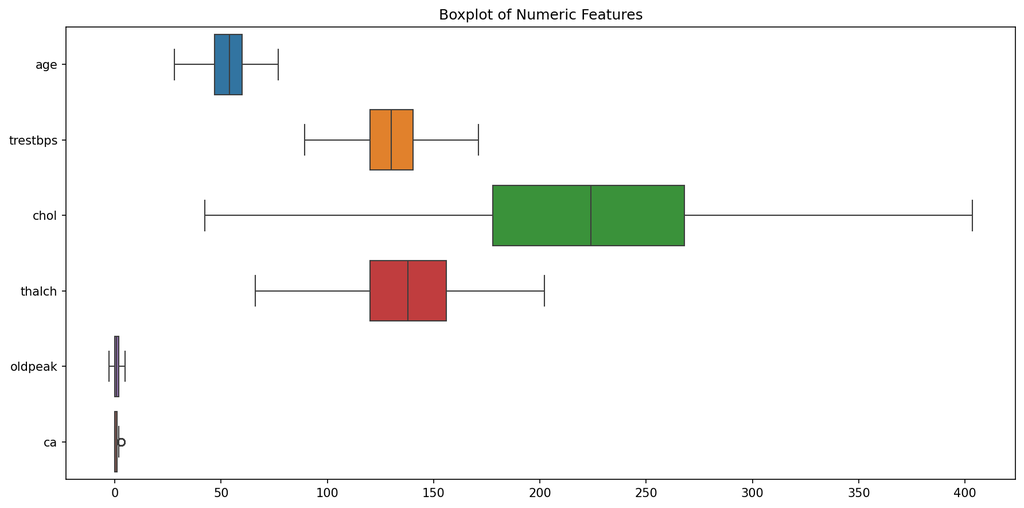

```python
# Boxplot to check for outliers
plt.figure(figsize=(12, 6))
sns.boxplot(data=df[numeric_features.columns], orient='h')
plt.title('Boxplot of Numeric Features')
plt.tight_layout()
plt.show()
```

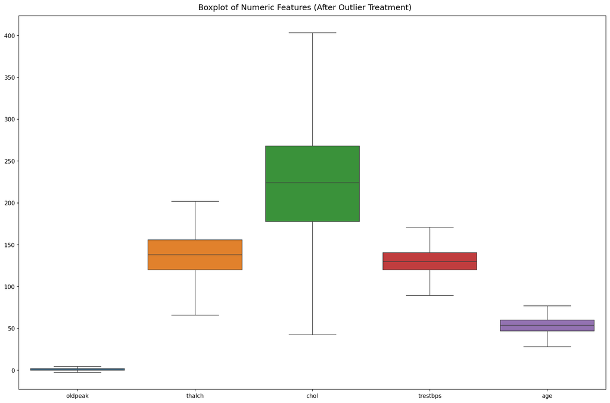

```python
# Plot the boxplot to check the outliers after treatment
plt.figure(figsize=(15, 10))
sns.boxplot(data=df[numeric_cols])
plt.suptitle('Boxplot of Numeric Features (After Outlier Treatment)', fontsize=14)
plt.tight_layout()
plt.show()
```

```python
# Check the maximum values of numeric columns
print(df[numeric_cols].max())
print('..................................................')
# Check the minimum values of numeric columns
print(df[numeric_cols].min())
# Store numerical features in a variable
continuous_features= df[numeric_cols]
continuous_features.head()
```

```
oldpeak       4.7500
thalch      202.0000
chol        403.3750
trestbps    170.9875
age          77.0000
dtype: float64
..................................................
oldpeak     -2.6000
thalch      66.0000
chol        42.3750
trestbps    89.4075
age         28.0000
dtype: float64
```

|  | oldpeak | thalch | chol | trestbps | age |
| --- | --- | --- | --- | --- | --- |
| 0 | 2.3 | 150.0 | 233.0 | 145.0 | 63 |
| 1 | 1.5 | 108.0 | 286.0 | 160.0 | 67 |
| 2 | 2.6 | 129.0 | 229.0 | 120.0 | 67 |
| 3 | 3.5 | 187.0 | 250.0 | 130.0 | 37 |
| 4 | 1.4 | 172.0 | 204.0 | 130.0 | 41 |

## 3. Model Training and Evaluation

```python
import numpy as np
import pandas as pd
import matplotlib.pyplot as plt

from sklearn.model_selection import train_test_split
from sklearn.pipeline import Pipeline
from sklearn.preprocessing import StandardScaler, OneHotEncoder
from sklearn.impute import SimpleImputer
from sklearn.compose import ColumnTransformer
from sklearn.metrics import (
    accuracy_score, precision_score, recall_score, f1_score, roc_auc_score,
    confusion_matrix, ConfusionMatrixDisplay, RocCurveDisplay
)
from sklearn.svm import SVC
from sklearn.ensemble import RandomForestClassifier
from sklearn.neighbors import KNeighborsClassifier
from xgboost import XGBClassifier


# Target + features
y_cls = (df["num"] > 0).astype(int)
X_cls = df.drop(columns=["num", "id", "dataset"], errors="ignore")

num_cols = X_cls.select_dtypes(include=["number"]).columns
cat_cols = X_cls.select_dtypes(exclude=["number"]).columns

numeric_transformer = Pipeline(steps=[
    ("imputer", SimpleImputer(strategy="median")),
    ("scaler", StandardScaler()),
])

categorical_transformer = Pipeline(steps=[
    ("imputer", SimpleImputer(strategy="most_frequent")),
    ("onehot", OneHotEncoder(handle_unknown="ignore")),
])

preprocess = ColumnTransformer(
    transformers=[
        ("num", numeric_transformer, num_cols),
        ("cat", categorical_transformer, cat_cols),
    ]
)

X_train, X_test, y_train, y_test = train_test_split(
    X_cls, y_cls, test_size=0.2, random_state=42, stratify=y_cls
)
```